# Professor Demographics in Film

Inspired by [this Washington Post article](https://www.washingtonpost.com/graphics/2020/entertainment/fictional-presidents-in-movies/) analyzing the demographics of actors who portrayed presidents in mopvies (they found that they were mostly portrayed by white males), I wanted to try a similar experiment with a portrayl of positions of power, relevant to my life: university professors.

## Obtaining Data

First, I need to find a list of movies that portray professors in some capacity. Fortunately, IMBD has tags for all of their movies, one of them being a "professor" tab. Each IMBD movie has a unique code which I need to obtain to iterate through the casts of these movies. `find_profmovies` will iterate through a list of all the movies on IMBD with the "professor" tag, obtain the IMBD codes, and store them in a list.

```python
import urllib
import re
from collections import OrderedDict

def find_profmovies(n, o):
    """
    iterates through a given list
    """
    totallist = []
    codes = []
    for i in range(n,o):
        url = "https://www.imdb.com/search/keyword/?keywords=professor&mode=detail&page="+ str(i)+"&ref_=kw_nxt&sort=moviemeter,asc&title_type=movie"
        # retrieve the data
        filedata = urllib.request.urlopen(url)
        # read as bytes
        bytes_text = filedata.read()
        # decode bytes to string
        html = bytes_text.decode("utf-8")

        pattern = r'alt="(.*)"'
        totallist += re.findall(pattern, html)

        pattern2 = r'<a href="/title/([\w]+)/'
        codes += re.findall(pattern2, html)

    codes = list(OrderedDict.fromkeys(codes))

    if len(totallist) == len(codes):
        D = {}
        for j in range(len(totallist)):
            D[totallist[j]] = codes[j]
    else:
        print("Lengths aren't equal")


    return totallist, codes, D
```

```python
movies, codes, Dcodes = find_profmovies(1, 28)
```

The template for accessing each individual movie's IMBD page is relatively simple: `https://www.imdb.com/title/` followed by the movie code. `gen_urls` will simply combine the base url and the movie code to generate a list of all the url's we eventually will need to scrape and store it in the list `urls`. It will also follow a similar template and store the urls of the full cast pages in the list `cast`.

```python
def gen_urls(movies, L):
    urls = []
    cast = []
    Dcast = {}
    for i in range(len(L)):
        urls.append("https://www.imdb.com/title/" + str(L[i]))
        cast.append("https://www.imdb.com/title/" + str(L[i]) + "/fullcredits?ref_=tt_cl_sm#cast")
        Dcast[movies[i]] = cast[i]
    return urls, cast, Dcast

urls, cast, Dcast = gen_urls(movies, codes)
```

```python
urls[312]
```

```
'https://www.imdb.com/title/tt0269743'
```

### Scraping Movie Data

Now comes a bit more tedious of a task: taking the data from each movie's IMBD page and converting it into a form that we can perform data analysis on. Now, there are several IMBD API's, but they are either very poorly documented or have a limit of 100 requests per day. The issue is I have 1000 movies, so web scrapping was the most viable path for me to get the data I needed efficently. I will be using the `requests` library to obtain the `html` markdown and the `BeautifulSoup` library to parse through the markdown to get the data I need.

```python
import requests
from bs4 import BeautifulSoup
```

In an effort to make my code more robust, I functionalized this process, creating a function for each task I wanted (getting the movie title, year, etc.) and combined those functions into a larger function. Each of these functions will take in a `soup` object to parse.

```python
import time

def gen_roles(soup):
    """
    takes in a soup object of the full cast page and returns a dictionary of the character name and the actor name
    """
    stop, count = 0,0
    character = []
    actor = []

    #find the breaking point of the main cast list
    for i in soup.select('.cast_list tr'):
        if i.get_text() == "Rest of cast listed alphabetically:":
            break
        stop +=1
    #find the character names
    for i in soup.find_all('td', class_ = "character"):
        try:
            character.append(i.find('a').get_text())
        except AttributeError:
            trial = i.get_text().split("\n")
            trial = [j for j in trial if j != ""]
            trial = [x.strip(' ') for x in trial]
            if len(trial) == 0:
                character.append("SKIPPED")
                continue
            character.append(str(trial[0]))
        count += 1
        if count == stop:
            count = 0
            break

    #find the actor names
    for i in soup.select("tr td img"):
        actor.append(i['alt'])
        count += 1
        if count == stop:
            count = 0
            break

    #put the actors and characters in a dict
    actor_dict = {}
    for i in range(len(actor)):
        actor_dict[character[i]] = actor[i]

    #make a dict of only the actors and characters who are professors
    prof_dict = {}
    prof_list = [i for i in list(actor_dict.keys()) if i[:4] == "Prof"]
    for i in prof_list:
        prof_dict[actor_dict[i]] = i

    return prof_dict
```

```python
def gen_genre(soup):
    """
    takes in a soup object of the movie page and extracts a list of the movie's genres as determined by IMBD
    """
    genrelist = []
    genres = soup.find_all(class_='see-more inline canwrap')[1]
    for i in genres.find_all('a'):
        genrelist.append(i.get_text().split()[0])
    return genrelist
```

```python
def gen_rating(soup):
    """
    takes in a soup object of the main movie page and returns the metacritic rating as a string
    """
    try:
        rating = int(soup.select('div .titleReviewBarItem span')[0].get_text())
    except ValueError:
        try:
            rating = soup.select('div .titleReviewBarItem span a')[1].get_text().split()[0]
        except IndexError:
            rating = "NONE"
    except IndexError:
        rating = "NONE"
    return rating
```

```python
def gen_year(soup):
    """
    takes in a soup object of the main movie page and returns the year the movie was released as a string
    """
    return soup.find(id="titleYear").get_text().split("(")[1].split(")")[0]
```

Finally, we will combine all of these functions into one giant `create_data` function, which will take in a range of movies and return a dictionary of relevant info for each professor character. Each index of the dictionary represents one character, and contains info about the movie the character is protrayed in as well as the actr. For example, the Harry Potter movies will take up several different indexes because there are multiple professors portrayed in each one.

The function determines whether or not a character is a professor by analyzing if their listed role contained the string "prof" in the `gen_roles` function. If none of the characters in the cast list meet this requirement, the function will skip over that movie and place the title in the list `no_profs`.

The parameter `skip` will add the movie information to the main dictionary if set to false. If set to true, it will not add movies without explicitly titled professors to the main dictionary.

```python
def create_data(x, skip = False, addnone = False):
    """
    takes in a range of movies and returns a JSON formated dictionary of info about each professor character
    """
    data = {}
    no_profs_data = {}
    no_profs = []
    count = 0
    starttt = time.time()
    # iterate through the inputed range
    for i in range(x):
        start_time = time.time()

        # get soup objects for the cast page
        castpage = requests.get(cast[i])
        cast_soup = BeautifulSoup(castpage.content, 'html.parser')
        role_list = gen_roles(cast_soup)

        #skip if there are no professors generated from the gen roles function and skip parameter is True
        if (len(role_list) == 0) and (skip == True):
            print("skipping")
            no_profs.append(movies[i])
            continue

        # get soup objects for main page
        summarypage = requests.get(urls[i])
        summary_soup = BeautifulSoup(summarypage.content, 'html.parser')

        year = gen_year(summary_soup)
        rating = gen_rating(summary_soup)
        genre_list = gen_genre(summary_soup)


        if len(role_list) != 0:
            for j in list(role_list.keys()):
                movie_info = {}
                movie_info["Name"] = movies[i]
                movie_info["Number"] = i #number of movie
                movie_info["Year"] = year #set year to year of movie
                movie_info["Actor"] = j  #set actors to a dict of actors and their charachters
                movie_info["Role"] = role_list[j]
                movie_info["Rating"] = rating
                for k in range(len(genre_list)):
                    movie_info["Genre " + str(k+1)] = genre_list[k]
                    if k == 3:
                        break;
                data[count] = movie_info #set key in data equal to movie name and value equal to the dictionary of movie info
                count += 1
            print("--- %s seconds ---" % round((time.time() - start_time), 2))
        # if skip parameter is false, add the movie to the main dictionary without character info
        elif len(role_list) == 0:
            movie_info = {}
            movie_info["Name"] = movies[i]
            movie_info["Number"] = i #number of movie
            movie_info["Role"] = role_list[j]
            movie_info["Rating"] = rating
            for k in range(2):
                movie_info["Genre " + str(k+1)] = genre_list[k]
            if addnone == False:
                data[count] = movie_info
            no_profs_data[count] = movie_info
            print("None --- %s seconds ---" % round((time.time() - start_time), 2))
            no_profs.append(movies[i])
            count += 1

    print(str(time.time() - starttt))
    return data, no_profs, no_profs_data
```

We will run this function on the first 1000 movies tagged 'professor.' I added some `print` statements to track the progress of the function and to see how many movies it skipped because there were no explicit professors.

```python
data, no_profs, no_profs_data = create_data(1000, True)
```

```
--- 2.89 seconds ---
skipping
skipping
--- 3.23 seconds ---
...
--- 2.18 seconds ---
skipping
skipping
1539.8896362781525
```

This is the result of the dictionary created, pretiffied:

```python
import json
print(json.dumps(data, sort_keys=False, indent=4))
```

```
{
    "0": {
        "Name": "Harry Potter and the Sorcerer's Stone",
        "Number": 0,
        "Year": "2001",
        "Actor": "Maggie Smith",
        "Role": "Professor McGonagall",
        "Rating": 64,
        "Genre 1": "Adventure",
        "Genre 2": "Family",
        "Genre 3": "Fantasy"
    },
    "1": {
        "Name": "Harry Potter and the Sorcerer's Stone",
        "Number": 0,
        "Year": "2001",
        "Actor": "Ian Hart",
        "Role": "Professor Quirrell",
        "Rating": 64,
        "Genre 1": "Adventure",
        "Genre 2": "Family",
        "Genre 3": "Fantasy"
    },
    "2": {
        "Name": "Harry Potter and the Sorcerer's Stone",
        "Number": 0,
        "Year": "2001",
        "Actor": "Alan Rickman",
        "Role": "Professor Snape",
        "Rating": 64,
        "Genre 1": "Adventure",
        "Genre 2": "Family",
        "Genre 3": "Fantasy"
    },
    ...
    "474": {
        "Name": "The Year That Trembled",
        "Number": 994,
        "Year": "2002",
        "Actor": "Matt Salinger",
```

[output cut: 10 more lines]

```
        "Actor": "Fabrizio Bentivoglio",
        "Role": "Prof. Bruno Beltrame",
        "Rating": "NONE",
        "Genre 1": "Comedy"
    },
    "476": {
        "Name": "Scialla! (Stai sereno)",
        "Number": 997,
        "Year": "2011",
        "Actor": "Raffaella Lebboroni",
        "Role": "Prof.ssa Di Biagio",
        "Rating": "NONE",
        "Genre 1": "Comedy"
    }
}
```

```python
no_profs
```

```
['Little Women',
 'Avengers: Endgame',
 'Inception',
 'Harry Potter and the Goblet of Fire',
 'Chitty Chitty Bang Bang',
 'Indiana Jones and the Raiders of the Lost Ark',
 'Call Me by Your Name',
 ...
 'A Witch Without a Broom',
 'The Seventh Room',
 'Urubú',
 'At kende sandheden',
 'Hide and Seek',
 'Kurôn wa kokyô wo mezasu',
 'Seeing Red']
```

We'll save the data as a json so we won't have to run the `create_data` function each time we start the kernel, because it takes quite a while, and will allow us to more easily manually inpuy new entries, which we will do with some of the movies that did not explicitly mention a professor in their credits.

```python
with open('data.json', 'w') as fp:
    json.dump(data, fp)
```

## Determining Gender

The simplelist demographic to analyze and compare is gender. I will determine the gender by analyzing the first names of the actors in the data dictionary. The list of male and female names is courtesy of geeksforgeeks.org. Now, in order to avoid miscoding names, there is some overlap between male and female names.

If a name is present in both of the lists, the `determine_gender` function will code the actor as `Both`. Then, I will manually go through and determine the gender of the actor. If the actor's name is not in either list, the function will classify it as `Unknown` and will similarly manually classify these actors.

```python
#load raw texts of lists
male = requests.get("https://media.geeksforgeeks.org/wp-content/uploads/male.txt").text.split("\n")
female = requests.get("https://media.geeksforgeeks.org/wp-content/uploads/female.txt").text.split("\n")
```

```python
def determine_gender(name):
    """
    takes in a name and outputs a gender by searching through the male and female lists
    """
    try:
        name = name.split()[0]
    except IndexError:
        return None
    name = name[0].upper() + name[1:]
    if name in male and name in female:
        return "Both"
    elif name in male:
        return "Male"
    elif name in female:
        return "Female"
    else:
        return "Unknown"
```

```python
determine_gender("Lawrence Parks")
```

```
'Male'
```

```python
determine_gender("Carrie Fisher")
```

```
'Female'
```

```python
determine_gender("Angie Smith")
```

```
'Both'
```

```python
determine_gender("Anze Kopitar")
```

```
'Unknown'
```

## Cleaning Data

We will now convert the json formatted data into a `pandas` data frame, making the data much more accessible for analysis and for manipulation

```python
import pandas as pd
```

```python
df = pd.read_json("data.json")
df = df.transpose()
df
```

|  | Name | Number | Year | Actor | Role | Rating | Genre 1 | Genre 2 | Genre 3 | Genre 4 |
| --- | --- | --- | --- | --- | --- | --- | --- | --- | --- | --- |
| 0 | Harry Potter and the Sorcerer's Stone | 0 | 2001 | Maggie Smith | Professor McGonagall | 64 | Adventure | Family | Fantasy | NaN |
| 1 | Harry Potter and the Sorcerer's Stone | 0 | 2001 | Ian Hart | Professor Quirrell | 64 | Adventure | Family | Fantasy | NaN |
| 2 | Harry Potter and the Sorcerer's Stone | 0 | 2001 | Alan Rickman | Professor Snape | 64 | Adventure | Family | Fantasy | NaN |
| 3 | Interstellar | 3 | 2014 | Michael Caine | Professor Brand | 74 | Adventure | Drama | Sci-Fi | NaN |
| 4 | The Wizard of Oz | 5 | 1939 | Frank Morgan | Professor Marvel | 92 | Adventure | Family | Fantasy | Musical |
| ... | ... | ... | ... | ... | ... | ... | ... | ... | ... | ... |
| 472 | Delivered | 986 | 1998 | Jeff Steitzer | Professor Freidman | NONE | Comedy | Drama | Thriller | NaN |
| 473 | Ramana | 990 | 2002 | Vijayakanth | Prof. Ramana | NONE | Action | Drama | NaN | NaN |
| 474 | The Year That Trembled | 994 | 2002 | Matt Salinger | Professor Jeff Griggs | 34 | Drama | Romance | War | NaN |
| 475 | Scialla! (Stai sereno) | 997 | 2011 | Fabrizio Bentivoglio | Prof. Bruno Beltrame | NONE | Comedy | NaN | NaN | NaN |
| 476 | Scialla! (Stai sereno) | 997 | 2011 | Raffaella Lebboroni | Prof.ssa Di Biagio | NONE | Comedy | NaN | NaN | NaN |

477 rows × 10 columns

Most of the movies do not have a third or fourth gender, so we will just remove those

```python
df = df.drop(["Genre 3","Genre 4"], axis = 1 )
df
```

|  | Name | Number | Year | Actor | Role | Rating | Genre 1 | Genre 2 |
| --- | --- | --- | --- | --- | --- | --- | --- | --- |
| 0 | Harry Potter and the Sorcerer's Stone | 0 | 2001 | Maggie Smith | Professor McGonagall | 64 | Adventure | Family |
| 1 | Harry Potter and the Sorcerer's Stone | 0 | 2001 | Ian Hart | Professor Quirrell | 64 | Adventure | Family |
| 2 | Harry Potter and the Sorcerer's Stone | 0 | 2001 | Alan Rickman | Professor Snape | 64 | Adventure | Family |
| 3 | Interstellar | 3 | 2014 | Michael Caine | Professor Brand | 74 | Adventure | Drama |
| 4 | The Wizard of Oz | 5 | 1939 | Frank Morgan | Professor Marvel | 92 | Adventure | Family |
| ... | ... | ... | ... | ... | ... | ... | ... | ... |
| 472 | Delivered | 986 | 1998 | Jeff Steitzer | Professor Freidman | NONE | Comedy | Drama |
| 473 | Ramana | 990 | 2002 | Vijayakanth | Prof. Ramana | NONE | Action | Drama |
| 474 | The Year That Trembled | 994 | 2002 | Matt Salinger | Professor Jeff Griggs | 34 | Drama | Romance |
| 475 | Scialla! (Stai sereno) | 997 | 2011 | Fabrizio Bentivoglio | Prof. Bruno Beltrame | NONE | Comedy | NaN |
| 476 | Scialla! (Stai sereno) | 997 | 2011 | Raffaella Lebboroni | Prof.ssa Di Biagio | NONE | Comedy | NaN |

477 rows × 8 columns

Next, we will apply our `determine_gender` function to the actors in the data frame and store the gender in a new column called "Gender."

```python
df_gender = df.copy()
df_gender["Gender"] = df_gender["Actor"].apply(determine_gender)
df_gender
```

|  | Name | Number | Year | Actor | Role | Rating | Genre 1 | Genre 2 | Gender |
| --- | --- | --- | --- | --- | --- | --- | --- | --- | --- |
| 0 | Harry Potter and the Sorcerer's Stone | 0 | 2001 | Maggie Smith | Professor McGonagall | 64 | Adventure | Family | Female |
| 1 | Harry Potter and the Sorcerer's Stone | 0 | 2001 | Ian Hart | Professor Quirrell | 64 | Adventure | Family | Male |
| 2 | Harry Potter and the Sorcerer's Stone | 0 | 2001 | Alan Rickman | Professor Snape | 64 | Adventure | Family | Male |
| 3 | Interstellar | 3 | 2014 | Michael Caine | Professor Brand | 74 | Adventure | Drama | Male |
| 4 | The Wizard of Oz | 5 | 1939 | Frank Morgan | Professor Marvel | 92 | Adventure | Family | Both |
| ... | ... | ... | ... | ... | ... | ... | ... | ... | ... |
| 472 | Delivered | 986 | 1998 | Jeff Steitzer | Professor Freidman | NONE | Comedy | Drama | Male |
| 473 | Ramana | 990 | 2002 | Vijayakanth | Prof. Ramana | NONE | Action | Drama | Unknown |
| 474 | The Year That Trembled | 994 | 2002 | Matt Salinger | Professor Jeff Griggs | 34 | Drama | Romance | Male |
| 475 | Scialla! (Stai sereno) | 997 | 2011 | Fabrizio Bentivoglio | Prof. Bruno Beltrame | NONE | Comedy | NaN | Unknown |
| 476 | Scialla! (Stai sereno) | 997 | 2011 | Raffaella Lebboroni | Prof.ssa Di Biagio | NONE | Comedy | NaN | Unknown |

477 rows × 9 columns

Let's see how many of each category (Male, Female, Both, and Unknown) we have at the moment.

```python
df_gender.groupby("Gender")[["Role"]].count()
```

| Gender | Role |
| --- | --- |
| Both | 57 |
| Female | 37 |
| Male | 283 |
| Unknown | 100 |

It looks like we will have about 157 entries to correct. Let's take a look at those classifed as "Both."

```python
df_gender[df_gender["Gender"] == "Both"]
```

|  | Name | Number | Year | Actor | Role | Rating | Genre 1 | Genre 2 | Gender |
| --- | --- | --- | --- | --- | --- | --- | --- | --- | --- |
| 4 | The Wizard of Oz | 5 | 1939 | Frank Morgan | Professor Marvel | 92 | Adventure | Family | Both |
| 29 | Indiana Jones and the Last Crusade | 19 | 1989 | Sean Connery | Professor Henry Jones | 65 | Action | Adventure | Both |
| 30 | Indiana Jones and the Last Crusade | 19 | 1989 | Jerry Harte | Professor Stanton | 65 | Action | Adventure | Both |
| 32 | Fast & Furious Presents: Hobbs & Shaw | 24 | 2019 | Eddie Marsan | Professor Andreiko | 60 | Action | Adventure | Both |
| 33 | The Italian Job | 31 | 1969 | Benny Hill | Professor Simon Peach | 70 | Action | Comedy | Both |
| 40 | Lucy | 50 | 2014 | Morgan Freeman | Professor Norman | 61 | Action | Sci-Fi | Both |
| 47 | Downfall | 66 | 2004 | Christian Berkel | Prof. Ernst-Günther Schenck | 82 | Biography | Drama | Both |
| 78 | Tolkien | 113 | 2019 | Andy Orchard | Professor #2 | 48 | Biography | Drama | Both |
| 79 | Timeline | 117 | 2003 | Billy Connolly | Professor Johnston | 28 | Action | Adventure | Both |
| 80 | Scary Movie 2 | 119 | 2001 | Tim Curry | Professor | 29 | Comedy | Horror | Both |
| 81 | Fallen | 121 | 1998 | Christian Aubert | Professor Louders | 65 | Action | Crime | Both |
| 86 | Ghost Stories | 133 | 2017 | Andy Nyman | Professor Goodman | 68 | Drama | Horror | Both |
| 90 | Back to School | 147 | 1986 | Sam Kinison | Professor Terguson | 68 | Comedy | Romance | Both |
| 113 | The Red Shoes | 189 | 1948 | Austin Trevor | Professor Palmer | 116 | Drama | Music | Both |
| 114 | The Day the Earth Stood Still | 196 | 1951 | Sam Jaffe | Professor Jacob Barnhardt | 136 | Drama | Sci-Fi | Both |
| 118 | On the Town | 206 | 1949 | George Meader | Professor | 71 | Comedy | Musical | Both |
| 119 | Funny Face | 207 | 1957 | Michel Auclair | Prof. Emile Flostre | 84 | Comedy | Musical | Both |
| 121 | The Roommate | 209 | 2011 | Billy Zane | Professor Roberts | 23 | Thriller | NaN | Both |
| 129 | Flubber | 222 | 1997 | Robin Williams | Professor Philip Brainard | 37 | Comedy | Family | Both |
| 159 | The Fantastic Four | 286 | 1994 | George Gaynes | Professor | 59 | Action | Adventure | Both |
| 160 | Little Nemo: Adventures in Slumberland | 291 | 1989 | Rene Auberjonois | Professor Genius | 25 | Animation | Adventure | Both |
| 161 | Going the Distance | 292 | 2010 | Terry Beaver | Professor | 51 | Comedy | Romance | Both |
| 170 | The Best of Youth | 301 | 2003 | Michele Melega | Professore di Lettere | 89 | Drama | Romance | Both |
| 171 | The Nutty Professor | 303 | 1963 | Jerry Lewis | Prof. Julius Kelp | 56 | Comedy | Romance | Both |
| 179 | Ball of Fire | 304 | 1941 | Aubrey Mather | Prof. Peagram | 78 | Comedy | Romance | Both |
| 190 | Teen Wolf Too | 331 | 1987 | Kim Darby | Professor Brooks | 8 | Comedy | Fantasy | Both |
| 205 | The Fourth Protocol | 369 | 1987 | Jerry Harte | Professor Krilov | 64 | Thriller | NaN | Both |
| 212 | The Absent Minded Professor | 386 | 1961 | Fred MacMurray | Professor Ned Brainard | 75 | Comedy | Family | Both |
| 231 | The Mortal Storm | 437 | 1940 | Frank Morgan | Professor Viktor Roth | 32 | Drama | NaN | Both |
| 237 | The Lost World | 444 | 1960 | Claude Rains | Prof. George Edward Challenger | 48 | Adventure | Fantasy | Both |
| 247 | Tall Story | 459 | 1960 | Ray Walston | Prof. Leo Sullivan | 9 | Comedy | Sport | Both |
| 250 | The Landlord | 467 | 1970 | Mel Stewart | Professor Duboise | 75 | Comedy | Drama | Both |
| 267 | Son of Flubber | 506 | 1963 | Fred MacMurray | Prof. Ned Brainard | 13 | Comedy | Sci-Fi | Both |
| 269 | Rivelazioni di un maniaco sessuale al capo del... | 507 | 1972 | Chris Avram | Professor Casali | 32 | Crime | Drama | Both |
| 298 | That Man from Rio | 560 | 1964 | Jean Servais | Prof. Norbert Catalan | 30 | Action | Adventure | Both |
| 308 | Shark | 581 | 1969 | Barry Sullivan | Prof. Dan Mallare | 24 | Action | Adventure | Both |
| 315 | 12:08 East of Bucharest | 595 | 2006 | Daniel Badale | Professor | 77 | Comedy | Drama | Both |
| 338 | Margie | 653 | 1946 | Glenn Langan | Prof. Ralph Fontayne | 5 | Comedy | Music | Both |
| 340 | 'Pimpernel' Smith | 661 | 1941 | Leslie Howard | Professor Horatio Smith | 8 | Adventure | Drama | Both |
| 342 | Konga | 667 | 1961 | George Pastell | Professor Tagore | 54 | Horror | Sci-Fi | Both |
| 354 | The Return of Count Yorga | 698 | 1971 | George Macready | Prof. Rightstat | 44 | Horror | NaN | Both |
| 361 | Bathing Beauty | 715 | 1944 | Bill Goodwin | Professor Willis Evans | 11 | Comedy | Musical | Both |
| 362 | Bathing Beauty | 715 | 1944 | Francis Pierlot | Professor Hendricks | 11 | Comedy | Musical | Both |
| 368 | Death Tunnel | 722 | 2005 | Gill Gayle | Professor | 35 | Horror | NaN | Both |
| 376 | The Mummy's Ghost | 749 | 1944 | Frank Reicher | Professor Norman | 44 | Fantasy | Horror | Both |
| 389 | Mother Is a Freshman | 772 | 1949 | Van Johnson | Professor Richard Michaels | 5 | Comedy | Romance | Both |
| 395 | Battle of the Worlds | 789 | 1961 | Claude Rains | Prof. Benson | 22 | Horror | Sci-Fi | Both |
| 398 | It Happens Every Spring | 797 | 1949 | Ray Milland | Prof. Vernon K. Simpson | 14 | Comedy | Sci-Fi | Both |
| 399 | It Happens Every Spring | 797 | 1949 | Ray Collins | Prof. Alfred Greenleaf | 14 | Comedy | Sci-Fi | Both |
| 419 | Mara and the Firebringer | 839 | 2015 | Jan Josef Liefers | Professor Weissinger | 35 | Drama | Fantasy | Both |
| 427 | Invitation | 862 | 1952 | Alex Gerry | Professor Redwick | NONE | Drama | Romance | Both |
| 431 | Love and Other Catastrophes | 871 | 1996 | Kim Gyngell | Professor Richard Leach | 58 | Comedy | Romance | Both |
| 439 | His Brother's Wife | 896 | 1936 | Jean Hersholt | Professor Fahrenheim | 1 | Drama | Romance | Both |
| 446 | Up and Down | 919 | 2004 | Jan Tríska | Professor Otakar Horecký | 78 | Comedy | Drama | Both |
| 457 | The Return of October | 943 | 1948 | Glenn Ford | Prof. Bentley 'Bass' Bassett Jr. | 5 | Comedy | Drama | Both |
| 459 | Good News | 947 | 1930 | Frank McGlynn Sr. | Prof. Kenyon | 2 | Comedy | Musical | Both |
| 461 | College Girls | 951 | 1968 | Sean O'Hara | Professor Bryce | 3 | Comedy | NaN | Both |

I am familiar with many of these actors, so I will change their entry from "Both" to "Male." For those who I was not familiar with, I researched them indivudally and changed their Gender accordingly.

```python
changers2 = [19,24,41,43,54,471,475,478,481]
for i in changes:
    if i in [229,276]:
        hi.loc[i]["Gender"] = "Female"
        continue
    elif i in [256,257,402]:
        continue
    hi.loc[i]["Gender"] = "Male"
```

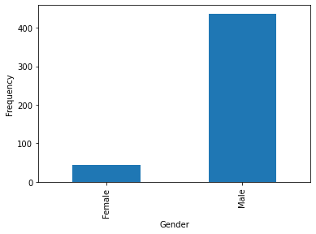

```python
hi.groupby("Gender")["Name"].count().plot(kind="bar").set_ylabel("Frequency")
```

```python
from matplotlib import pyplot as plt
import seaborn as sns
import numpy as np
sns.set()
```

[figure not shown]

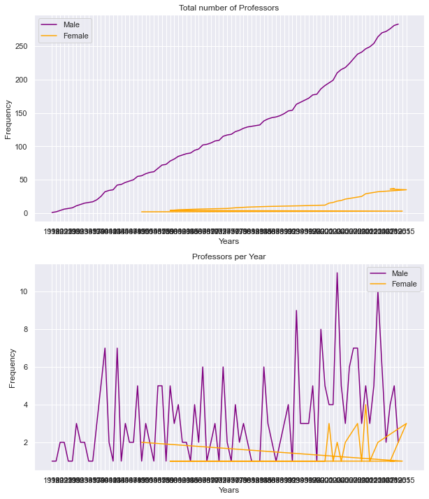

```python
by_year = hi.groupby(["Gender","Year"])[["Actor"]].count()
fig, ax = plt.subplots(2, 2, figsize = (20,10))


ax[0,0].plot(by_year.loc["Female"].index.get_level_values(0), by_year.loc["Female"].cumsum(), c = "Orange")
ax[0,0].set(xlabel = "Years", ylabel = "Frequency", title = "Total Female Professors")

ax[0,1].plot(by_year.loc["Female"].index.get_level_values(0), by_year.loc["Female"], c = "Orange")
ax[0,1].set(xlabel = "Years", ylabel = "Frequency", title = "Female Professors per year")

ax[1,0].plot(by_year.loc["Male"].index.get_level_values(0), by_year.loc["Male"].cumsum(), c = "Purple")
ax[1,0].set(xlabel = "Years", ylabel = "Frequency", title = "Total Male Professors",)

ax[1,1].plot(by_year.loc["Male"].index.get_level_values(0), by_year.loc["Male"], c = "Purple")
ax[1,1].set(xlabel = "Years", ylabel = "Frequency", title = "Male Professors per year")
fig.show()

fig, ax = plt.subplots(2, figsize=(10,12))
ax[0].plot(by_year.loc["Male"].index.get_level_values(0), by_year.loc["Male"].cumsum(), c = "Purple", label = "Male")
ax[0].plot(by_year.loc["Female"].index.get_level_values(0), by_year.loc["Female"].cumsum(), c = "Orange", label = "Female")
ax[0].legend()
ax[0].set(xlabel = "Years", ylabel = "Frequency", title = "Total number of Professors")

ax[1].plot(by_year.loc["Male"].index.get_level_values(0), by_year.loc["Male"], c = "Purple", label = "Male")
ax[1].plot(by_year.loc["Female"].index.get_level_values(0), by_year.loc["Female"], c = "Orange", label = "Female")
ax[1].legend()
ax[1].set(xlabel = "Years", ylabel = "Frequency", title = "Professors per Year")
fig.show()
```

```python
import plotly.graph_objects as go
fig = go.Figure(data=go.Bar(y=[2, 3, 1]))
fig.show()
```

[interactive chart not shown]

```python
np.arrange
```